# Hands-on Exercise 2: Beyond ggplot2 Fundamentals

Author

Andy Tai

Published

April 18, 2026

Modified

April 25, 2026

## 1 Overview

In this chapter, we will be learning about ggplot2 extensions for creating more elegant and effective statistical graphics. The goals of this exercise is to:

- control the placement of annotation on a graph by using functions provided in ggrepel package,
- create professional publication quality figure by using functions provided in ggthemes and hrbrthemes packages, and
- plot composite figure by combining ggplot2 graphs by using patchwork package.

## 2 Getting Started

**Installing and loading libraries**

In this exercise, beside tidyverse, four R packages will be used. They are:

- [ggrepel](https://cran.r-project.org/web/packages/ggrepel/vignettes/ggrepel.html): an R package provides geoms for ggplot2 to repel overlapping text labels.
- [ggthemes](https://ggplot2.tidyverse.org/reference/ggtheme.html): an R package provides some extra themes, geoms, and scales for ‘ggplot2’.
- [hrbrthemes](https://r-graph-gallery.com/package/hrbrthemes.html): an R package provides typography-centric themes and theme components for ggplot2.
- [patchwork](https://patchwork.data-imaginist.com/): an R package for preparing composite figure created using ggplot2.

Code chunk below will be used to check if these packages have been installed and also will load them onto your working R environment.

```r
pacman::p_load(ggrepel, patchwork,
               ggthemes, hrbrthemes,
               tidyverse, ggpmisc)
```

**Importing Data**

- The code chunk below imports **exam_data.csv** into R environment by using [read_csv()](https://readr.tidyverse.org/reference/read_delim.html) function of [readr](https://readr.tidyverse.org/) package.
- readr is one of the tidyverse package.

```r
exam_data <- read_csv("data/Exam_data.csv")
```

**Understanding the Data**

```r
glimpse(exam_data)
```

```
Rows: 322
Columns: 7
$ ID      <chr> "Student321", "Student305", "Student289", "Student227", "Stude…
$ CLASS   <chr> "3I", "3I", "3H", "3F", "3I", "3I", "3I", "3I", "3I", "3H", "3…
$ GENDER  <chr> "Male", "Female", "Male", "Male", "Male", "Female", "Male", "M…
$ RACE    <chr> "Malay", "Malay", "Chinese", "Chinese", "Malay", "Malay", "Chi…
$ ENGLISH <dbl> 21, 24, 26, 27, 27, 31, 31, 31, 33, 34, 34, 36, 36, 36, 37, 38…
$ MATHS   <dbl> 9, 22, 16, 77, 11, 16, 21, 18, 19, 49, 39, 35, 23, 36, 49, 30,…
$ SCIENCE <dbl> 15, 16, 16, 31, 25, 16, 25, 27, 15, 37, 42, 22, 32, 36, 35, 45…
```

- Year end examination grades of a cohort of primary 3 students from a local school.
- There are a total of seven attributes. Four of them are categorical data type and the other three are in continuous data type.
  - Categorical attributes are: ID, CLASS, GENDER and RACE.
  - Continuous attributes are: MATHS, ENGLISH and SCIENCE.

## 3 Beyond ggplot2 Annotation: ggrepel

**Data annotations**

One of the challenge in plotting statistical graph is annotation, especially with large number of data points. Note that there are a lot of labels, and they seems to be crowding out the key data points.

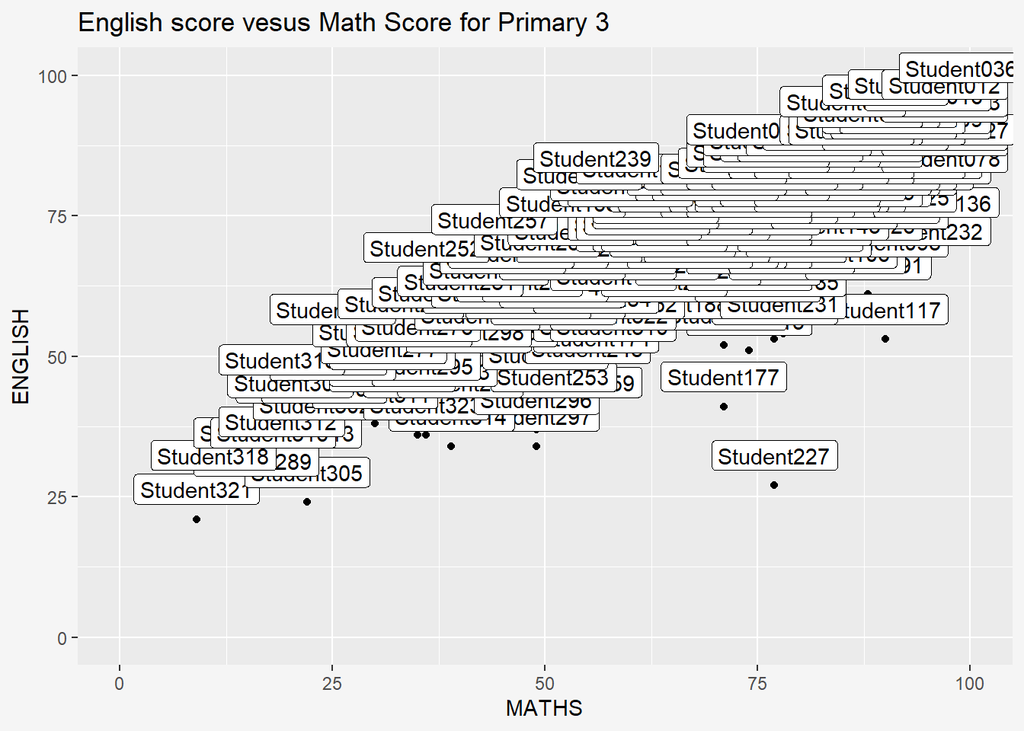

```r
ggplot(data=exam_data,
       aes(y=ENGLISH, x=MATHS)) +
  geom_point() +
  geom_smooth(method=lm, size = 0.5) +
  coord_cartesian(xlim=c(0,100),
                       ylim=c(0,100)) +
  geom_label(aes(label=ID),
             hjust=0.5,
             vjust=-0.5) +
  ggtitle('English score vesus Math Score for Primary 3')+
  theme(plot.background=element_rect(fill="#f5f5f5",colour="#f5f5f5"))
```

**repelling labels**

[ggrepel](https://cran.r-project.org/web/packages/ggrepel/vignettes/ggrepel.html) is an extension of ggplot2 package which provides `geoms` for ggplot2 to repel overlapping text as in our example above.

To implement this, we simply replace `geom_text()` by [geom_text_repel()](https://ggrepel.slowkow.com/reference/geom_text_repel.html) and `geom_label()` by [geom_label_repel](https://ggrepel.slowkow.com/reference/geom_text_repel.html). The example below illustrates the latter.

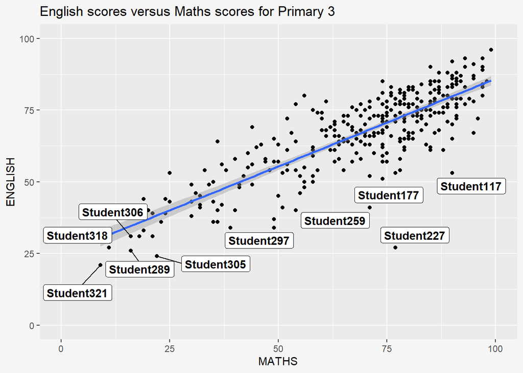

```r
ggplot(data=exam_data,
       aes(x= MATHS,
           y=ENGLISH)) +
  geom_point() +
  geom_smooth(method=lm,
              size=1) +
  geom_label_repel(aes(label = ID),
                   fontface = "bold",
                   max.overlaps = 15) +  #Labels increase as max overlaps increase
  coord_cartesian(xlim=c(0,100),
                  ylim=c(0,100)) +
  ggtitle("English scores versus Maths scores for Primary 3")+
  theme(plot.background=element_rect(fill="#f5f5f5",colour="#f5f5f5"))
```

## 4 Beyond ggplot2 Themes

### 4.1 Built-in ggplot2 themes

ggplot2 comes with eight built-in themes:

- theme_gray(),
- theme_bw(),
- theme_classic(),
- theme_dark(),
- theme_light(),
- theme_linedraw(),
- theme_minimal(), and
- theme_void().

**theme_gray()**

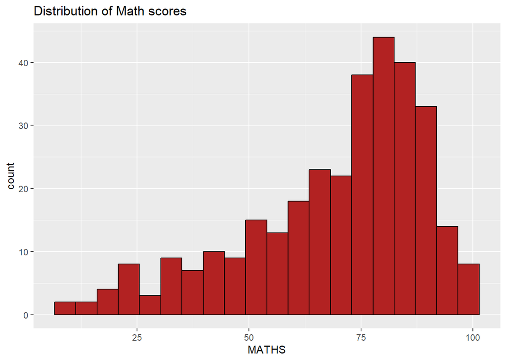

```r
ggplot(data=exam_data,
       aes(x=MATHS)) +
  geom_histogram(bins=20,
                 color= 'black',
                 fill='firebrick') +
   ggtitle('Distribution of Math scores')+
  theme_gray()
```

**theme_bw()**

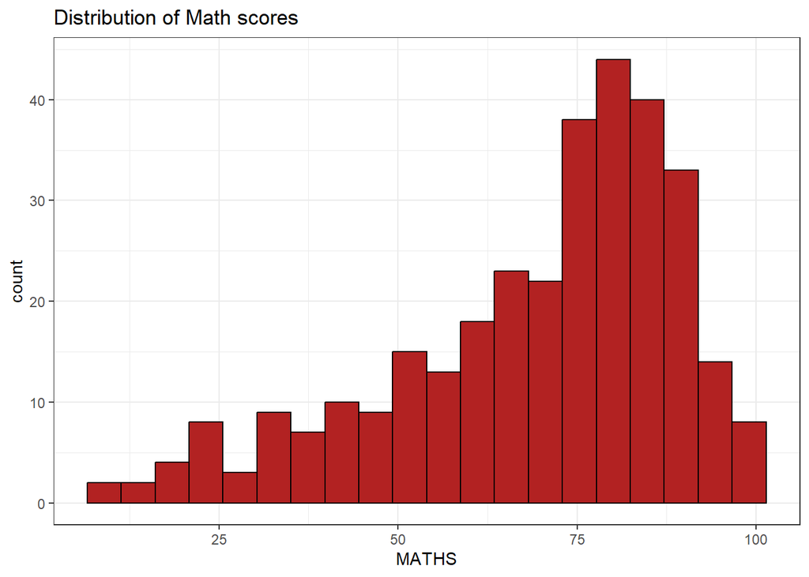

```r
ggplot(data=exam_data,
       aes(x=MATHS)) +
  geom_histogram(bins=20,
                 color= 'black',
                 fill='firebrick') +
  ggtitle('Distribution of Math scores')+
   theme_bw()
```

**theme_classic()**

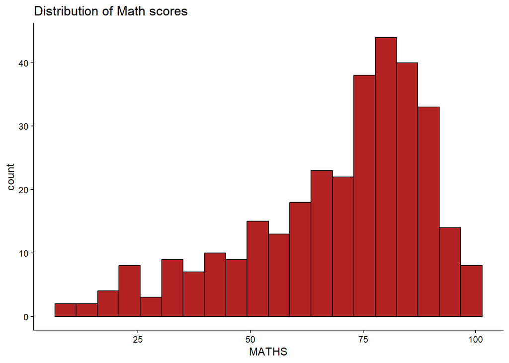

```r
ggplot(data=exam_data,
       aes(x=MATHS)) +
  geom_histogram(bins=20,
                 color= 'black',
                 fill='firebrick') +
  ggtitle('Distribution of Math scores')+
  theme_classic()
```

**theme_dark()**

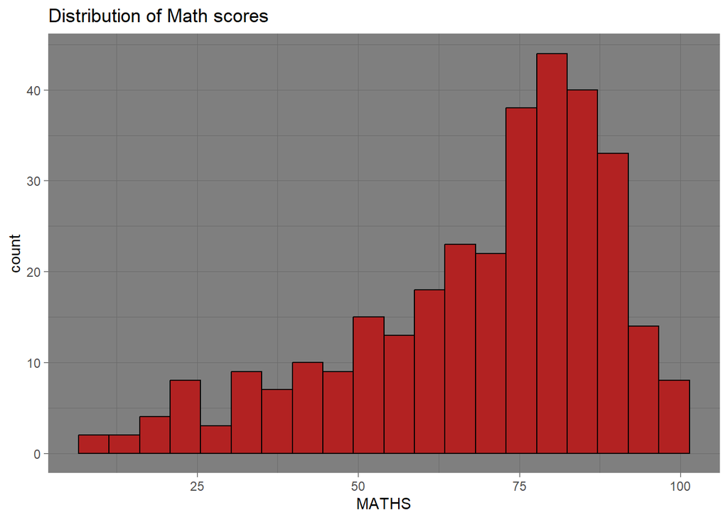

```r
ggplot(data=exam_data,
       aes(x=MATHS)) +
  geom_histogram(bins=20,
                 color= 'black',
                 fill='firebrick') +
  ggtitle('Distribution of Math scores')+
   theme_dark()
```

**theme_light()**

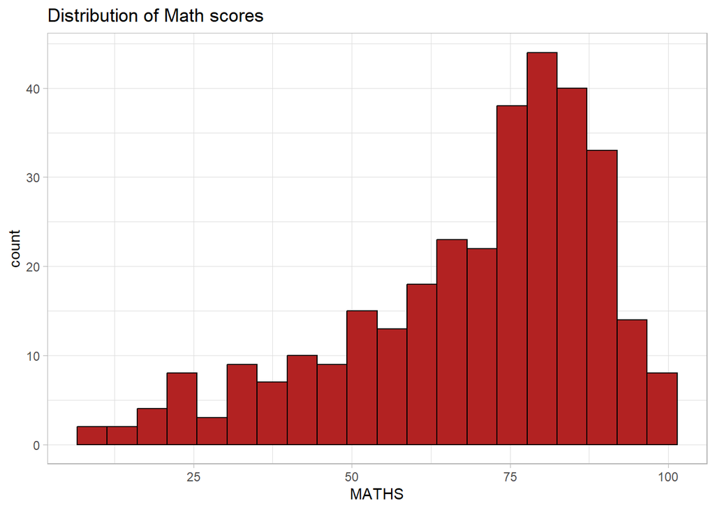

```r
ggplot(data=exam_data,
       aes(x=MATHS)) +
  geom_histogram(bins=20,
                 color= 'black',
                 fill='firebrick') +
  ggtitle('Distribution of Math scores')+
  theme_light()
```

**theme_linedraw()**

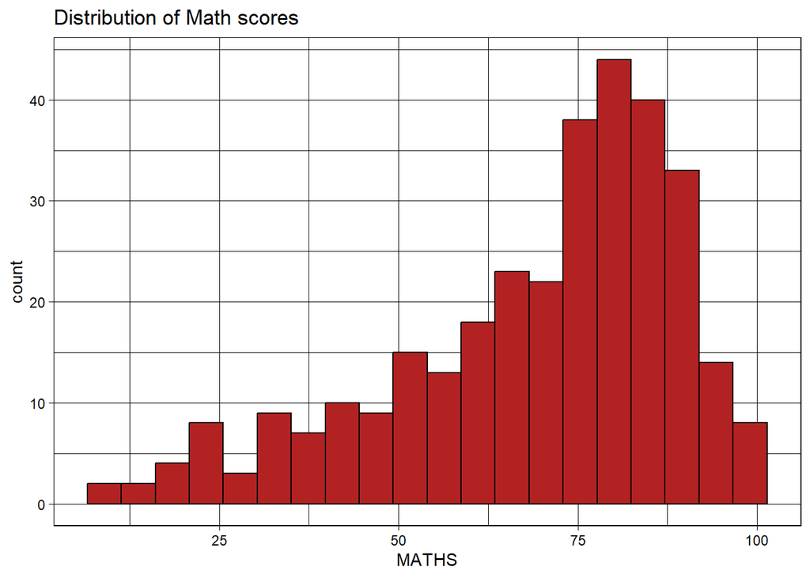

```r
ggplot(data=exam_data,
       aes(x=MATHS)) +
  geom_histogram(bins=20,
                 color= 'black',
                 fill='firebrick') +
  ggtitle('Distribution of Math scores')+
  theme_linedraw()
```

**theme_minimal()**

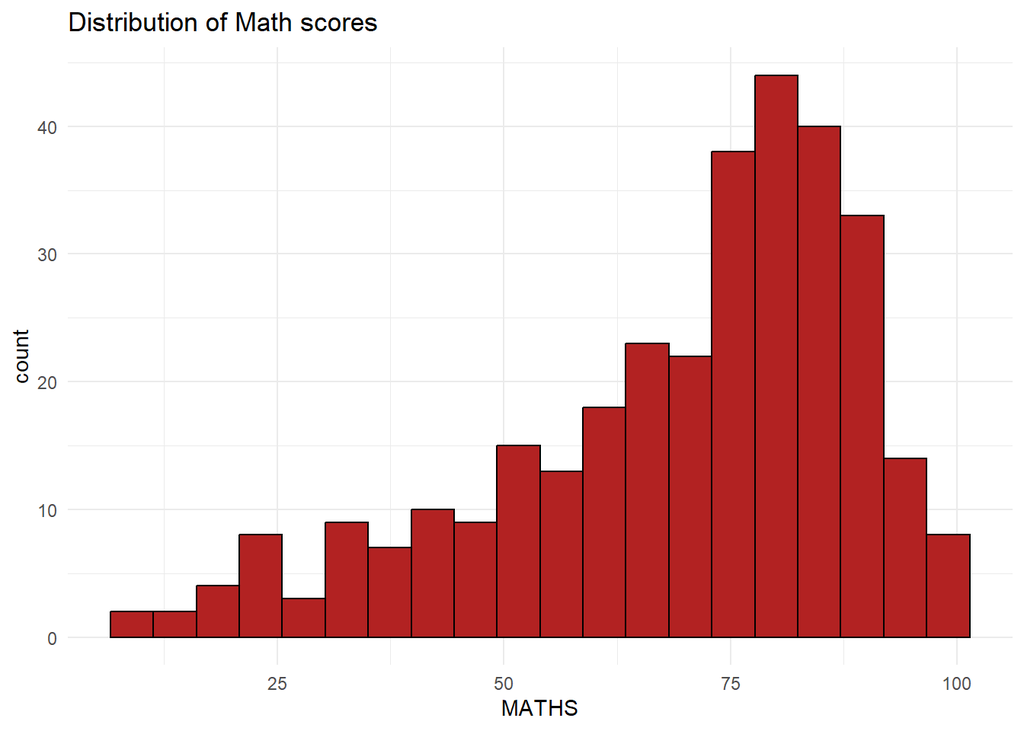

```r
ggplot(data=exam_data,
       aes(x=MATHS)) +
  geom_histogram(bins=20,
                 color= 'black',
                 fill='firebrick') +
  ggtitle('Distribution of Math scores')+
  theme_minimal()
```

**theme_void()**

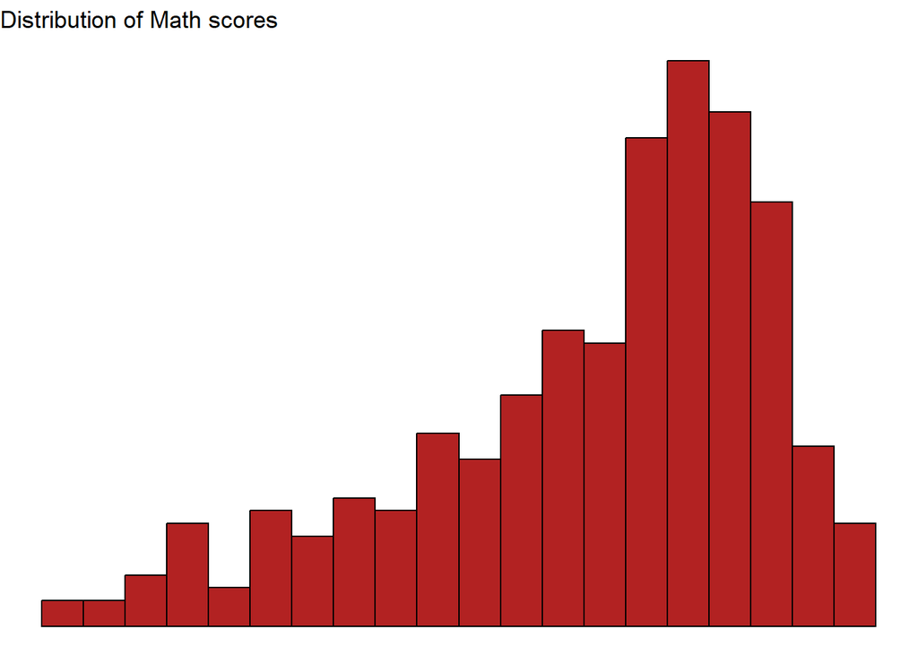

```r
ggplot(data=exam_data,
       aes(x=MATHS)) +
  geom_histogram(bins=20,
                 color= 'black',
                 fill='firebrick') +
  ggtitle('Distribution of Math scores')+
  theme_void()
```

## 4.2 Working with ggtheme package

[ggthemes](https://ggplot2.tidyverse.org/reference/ggtheme.html) provides [‘ggplot2’ themes](https://yutannihilation.github.io/allYourFigureAreBelongToUs/ggthemes/) that replicate the look of plots by Edward Tufte, Stephen Few, [Fivethirtyeight](https://fivethirtyeight.com/tag/data-visualization/), [The Economist](https://www.economist.com/topics/graphic-detail), ‘Stata’, ‘Excel’, and [The Wall Street Journal](https://www.pinterest.com/wsjgraphics/wsj-graphics/), among others.

**theme_economist**

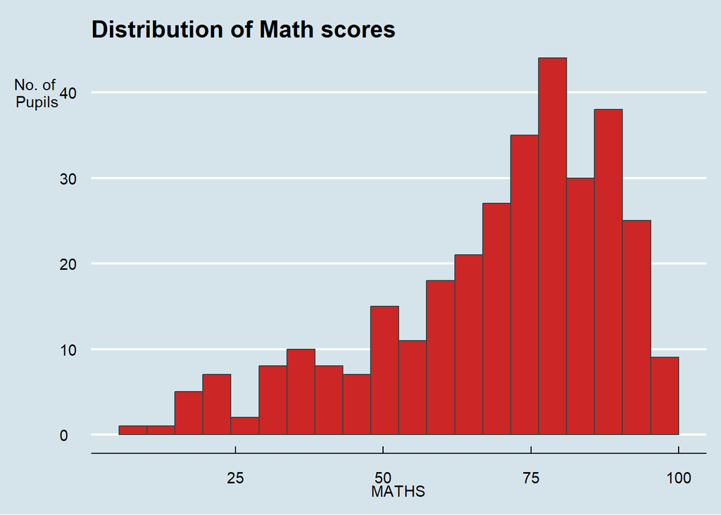

```r
ggplot(data=exam_data,
       aes(x=MATHS)) +
  geom_histogram(bins=20,
                 boundary=100,
                 color='grey25',
                 fill='firebrick3',size=0.8) +
  theme_economist() +
  labs(y= 'No. of \nPupils') +
  theme(axis.title.y=element_text(angle = 0,
                                  vjust=0.9)) +
  ggtitle('Distribution of Math scores')
```

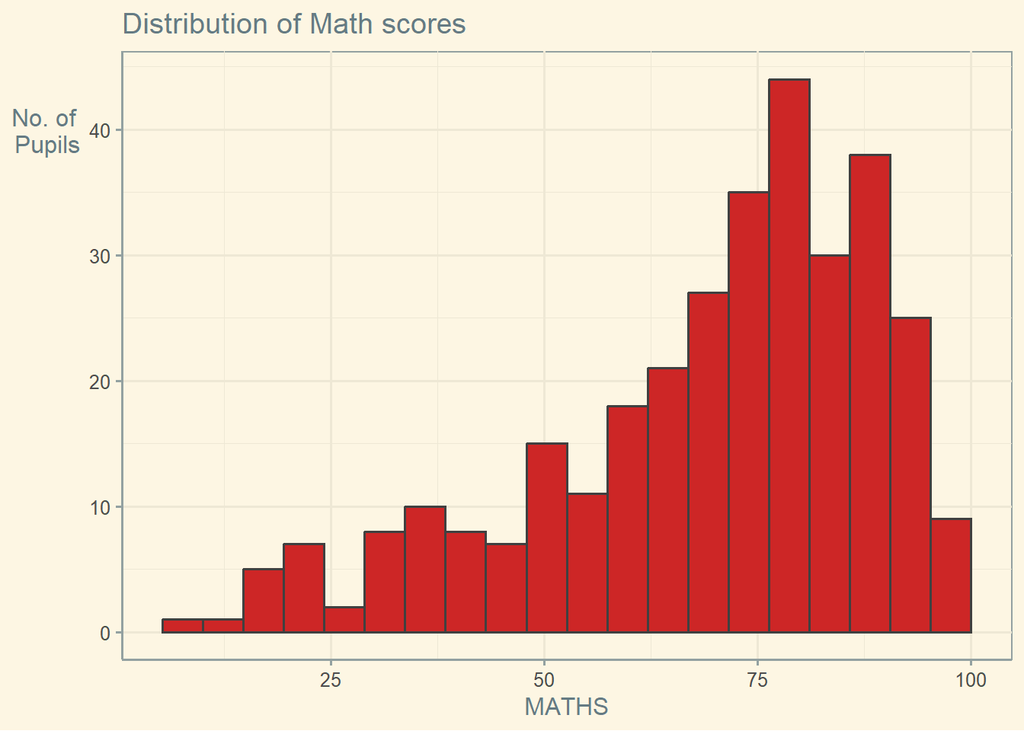

```r
ggplot(data=exam_data,
       aes(x=MATHS)) +
  geom_histogram(bins=20,
                 boundary=100,
                 color='grey25',
                 fill='firebrick3',size=0.8) +
  theme_solarized() +
  labs(y= 'No. of \nPupils') +
  theme(axis.title.y=element_text(angle = 0,
                                  vjust=0.9)) +
  ggtitle('Distribution of Math scores')
```

It also provides some extra geoms and scales for ‘ggplot2’. Refer to this [vignette](https://yutannihilation.github.io/allYourFigureAreBelongToUs/ggthemes/) to learn more.

## 4.3 Working with hrbthems package

[hrbrthemes](https://r-graph-gallery.com/package/hrbrthemes.html) package provides a base theme that focuses on typographic elements, including where various labels are placed as well as the fonts that are used. The second goal centers around productivity for a production workflow. In fact, this “production workflow” is the context for where the elements of hrbrthemes should be used.

**Original**

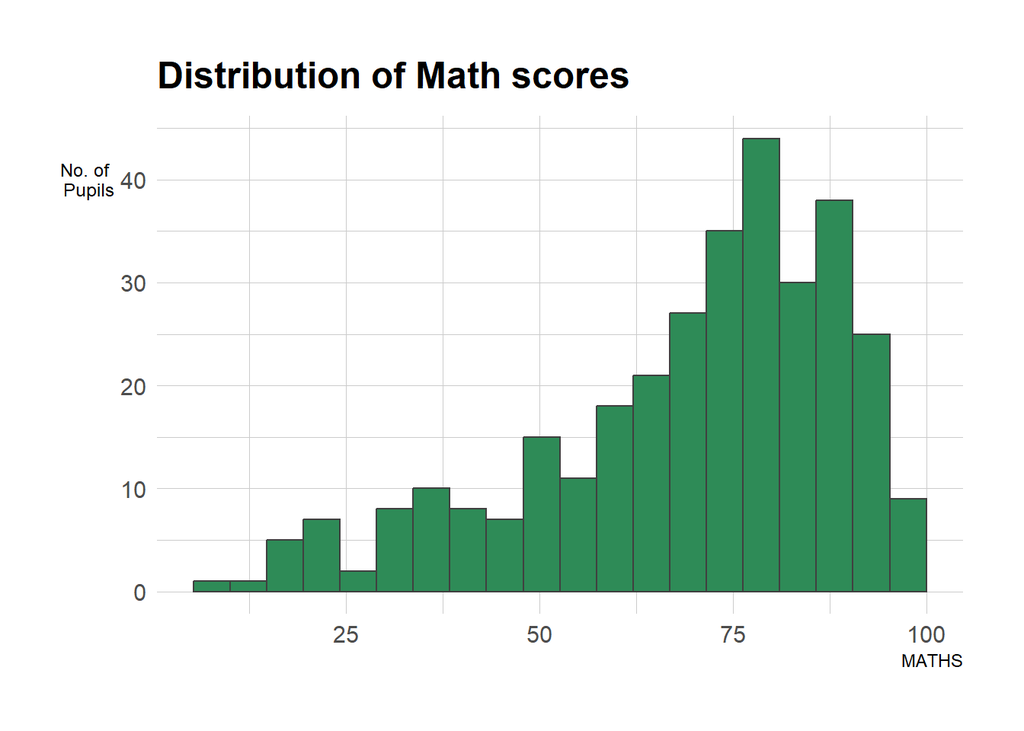

```r
ggplot(data=exam_data,
       aes(x=MATHS)) +
  geom_histogram(bins=20,
                 boundary=100,
                 color='grey25',
                 fill='seagreen') +
  theme_ipsum() +
  labs(y= 'No. of \nPupils') +
  theme(axis.title.y=element_text(angle = 0,
                                  vjust=0.9)) +
  ggtitle('Distribution of Math scores')
```

**With Elements**

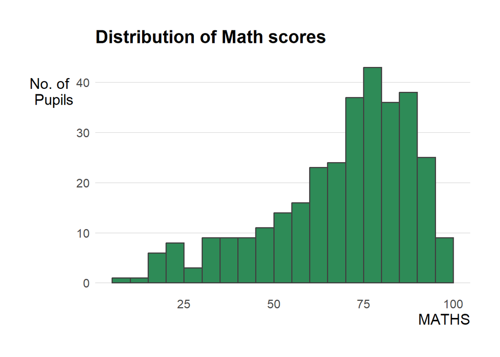

```r
ggplot(data=exam_data,
       aes(x=MATHS)) +
  geom_histogram(binwidth=5,
                 boundary=100,
                 color='grey25',
                 fill='seagreen') +
  theme_ipsum(axis_title_size = 15,
              base_size=12,
              grid= 'Y') +
 labs(y= 'No. of \nPupils') +
 theme(axis.title.y=element_text(angle = 0,
                                  vjust=0.9)) +
  ggtitle('Distribution of Math scores')
```

- axis_title_size argument is used to increase the font size of the axis title to 15,
- base_size argument is used to increase the default axis label to 12, and
- grid argument is used to remove the x-axis grid lines.

## 5 Beyond Single Graph

It is not unusual that multiple graphs are required to tell a compelling visual story. There are several ggplot2 extensions provide functions to compose figure with multiple graphs. In this section, we create composite plot by combining multiple graphs. First, create three statistical graphics by using the code chunk below.

**Maths Scores**

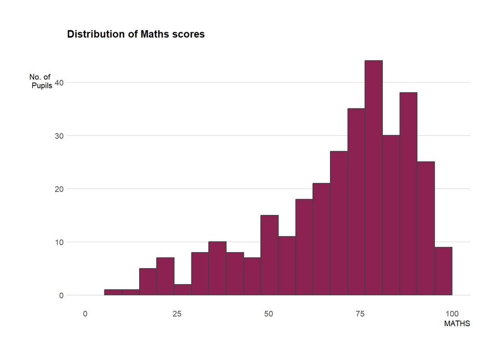

```r
p1 <- ggplot(data=exam_data,
       aes(x=MATHS)) +
  geom_histogram(bins=20,
                 boundary=100,
                 color='grey25',
                 fill='violetred4') +
  coord_cartesian(xlim=c(0,100)) +
  theme_ipsum(axis_title_size = 8,
              base_size=8,
              grid= 'Y') +
 labs(y= 'No. of \nPupils',
      title ='Distribution of Maths scores') +
 theme(axis.title.y=element_text(angle = 0,
                                  vjust=0.9),
       plot.title=element_text(size =10))

p1
```

**English Scores**

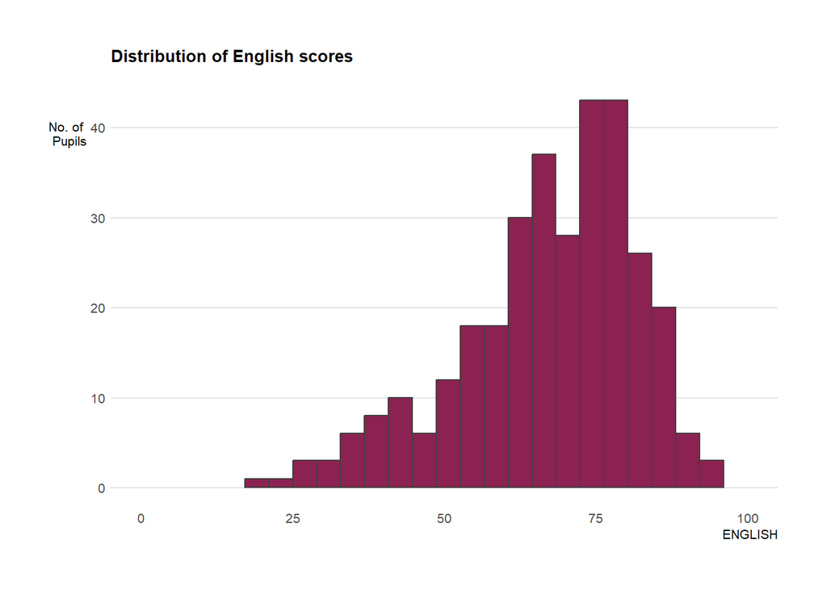

```r
p2 <- ggplot(data=exam_data,
       aes(x=ENGLISH)) +
  geom_histogram(bins=20,
                 boundary=100,
                 color='grey25',
                 fill='violetred4') +
  coord_cartesian(xlim=c(0,100)) +
  theme_ipsum(axis_title_size = 8,
              base_size=8,
              grid= 'Y') +
 labs(y= 'No. of \nPupils',
      title= 'Distribution of English scores') +
 theme(axis.title.y=element_text(angle = 0,
                                  vjust=0.9),
       plot.title=element_text(size =10))

p2
```

**Scatterplot of English vs Maths Scores**

A simple scatter plot can illustrate relationship between two features.

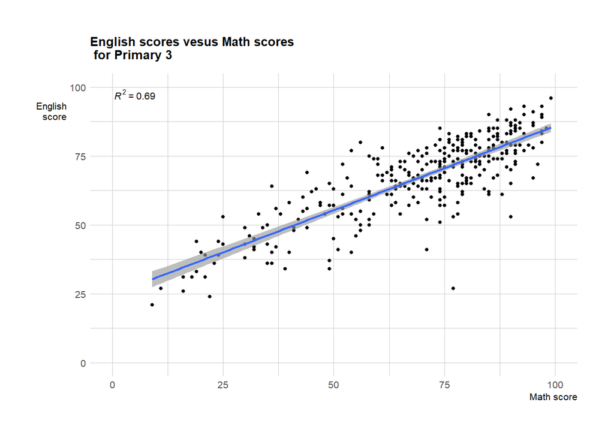

```r
p3 <- ggplot(data=exam_data,
       aes(x=MATHS, y=ENGLISH)) +
  geom_point() +
  geom_smooth(method=lm,
              size = 0.5 )+
  stat_poly_line() +
  stat_poly_eq() +
  coord_cartesian(xlim=c(0,100),
                  ylim=c(0,100)) +
  theme_ipsum(axis_title_size = 8,
              base_size=8) +
 labs(y= 'English\n score', x= 'Math score',
      title= 'English scores vesus Math scores\n for Primary 3') +
 theme(axis.title.y=element_text(angle = 0,
                                  vjust=0.9),
       plot.title=element_text(size =10))

p3
```

## 5.1 Creating Composite Graphics: pathwork methods

There are several ggplot2 extension’s functions support the needs to prepare composite figure by combining several graphs such as `grid.arrange()` of **gridExtra** package and `plot_grid()` of [cowplot](https://wilkelab.org/cowplot/) package. In this section, we use ggplot2 extension called [patchwork](https://patchwork.data-imaginist.com/) which is specially designed for combining separate ggplot2 graphs into a single figure.

Patchwork package has a very simple syntax, such as:

- Two-Column Layout using the Plus Sign +.
- Parenthesis () to create a subplot group.
- Two-Row Layout using the Division Sign /

## 5.2 Combining two ggplot2 graphs

Figure below shows a composite of two histograms created using patchwork.

**Horizontal**

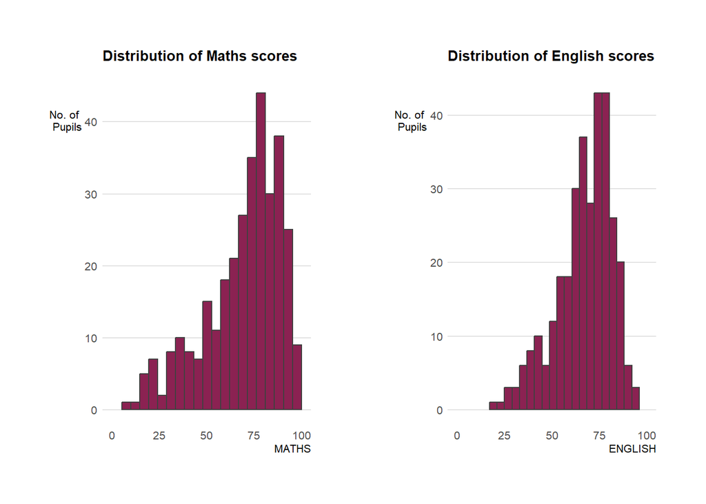

```r
p1 + p2
```

**Vertical**

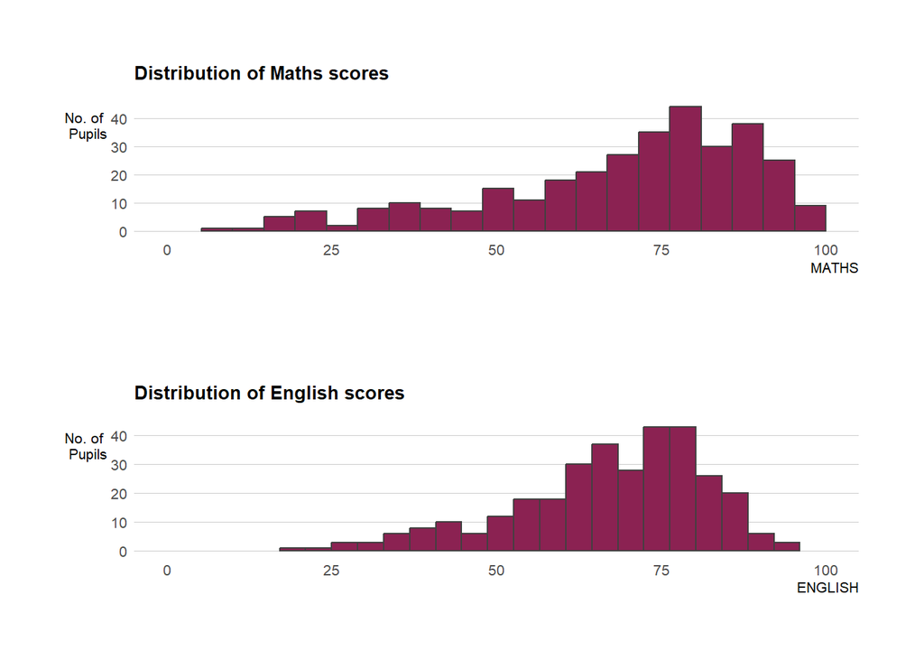

```r
p1 / p2
```

**Change Relative Area**

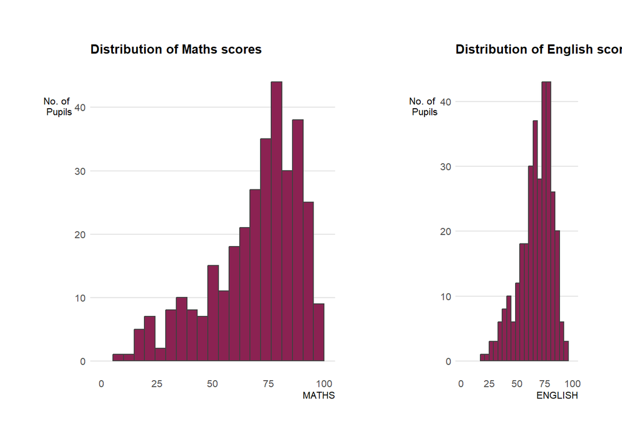

```r
p1 + p2 + plot_layout(ncol=2,widths=c(2,1))
```

## 5.3 Combining three ggplot2 graphs

We can plot more complex composite by using appropriate operators. For example, the composite figure below is plotted by using:

**/ and | Operators**

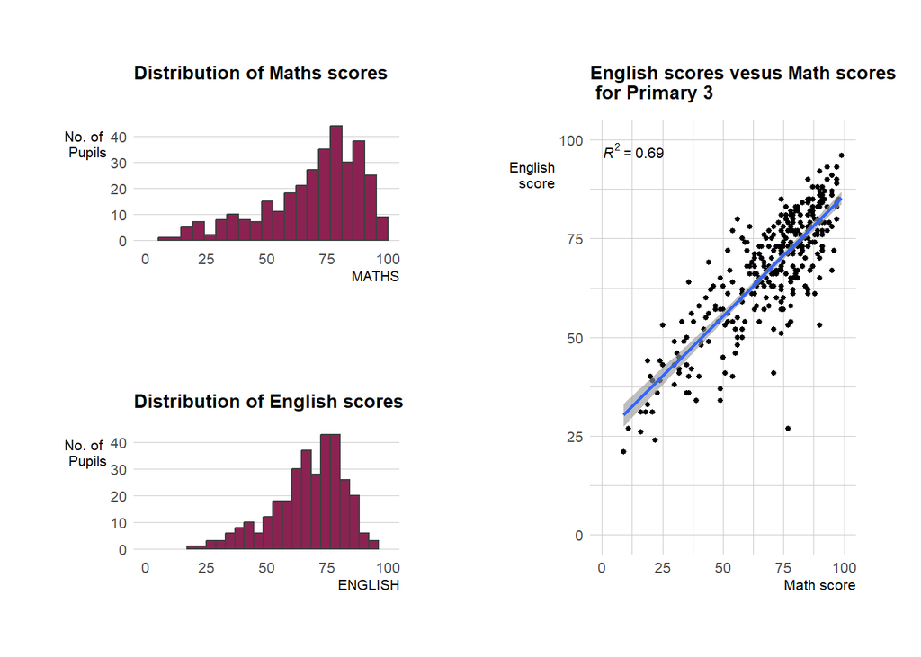

```r
(p1 / p2) | p3
```

**- Operator for Subtrack Placement**

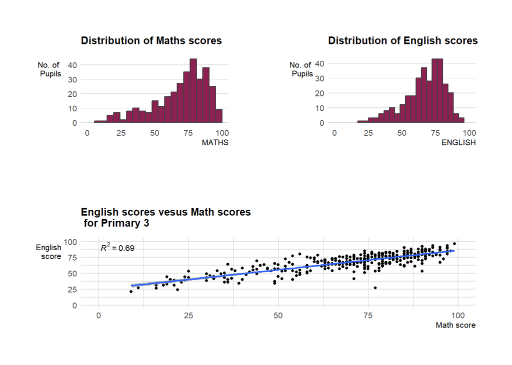

```r
p1 + p2 - p3 + plot_layout(ncol=1)
```

**Nested Layouts**

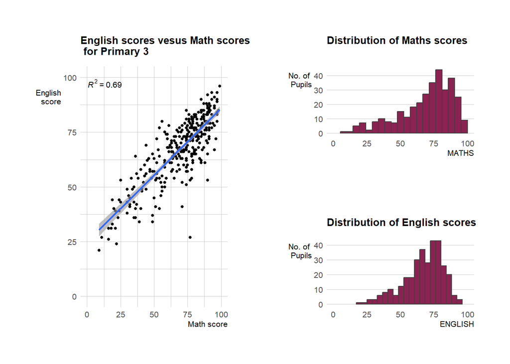

```r
p3 + {
  p1 + p2 + plot_layout(ncol=1)
}
```

**Adding non-ggplot content**

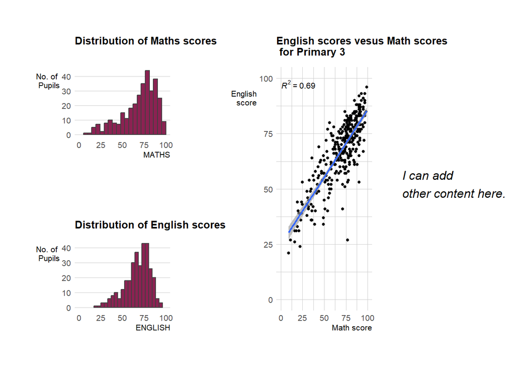

```r
((p1 / p2) | p3) + grid:: textGrob('I can add \nother content here.',
                                   hjust=0,
                                   x=-0,
                                   gp=grid::gpar(font=3,
                                                 fontsize = 12))
```

To learn more about, refer to [Plot Assembly](https://patchwork.data-imaginist.com/articles/guides/assembly.html).

## 5.4 Creating a composite figure with tag

In order to identify subplots in text, patchwork also provides auto-tagging capabilities as shown in the figure below.

**Enumeration**

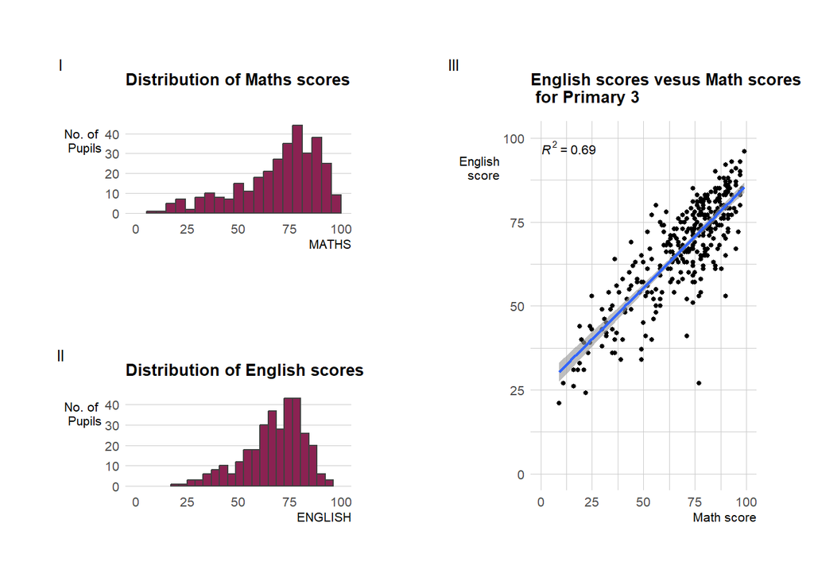

```r
((p1 / p2) | p3) +
  plot_annotation(tag_levels = 'I') # Can also use tag_levels ='A'
```

**Custom / Multilevel Tagging**

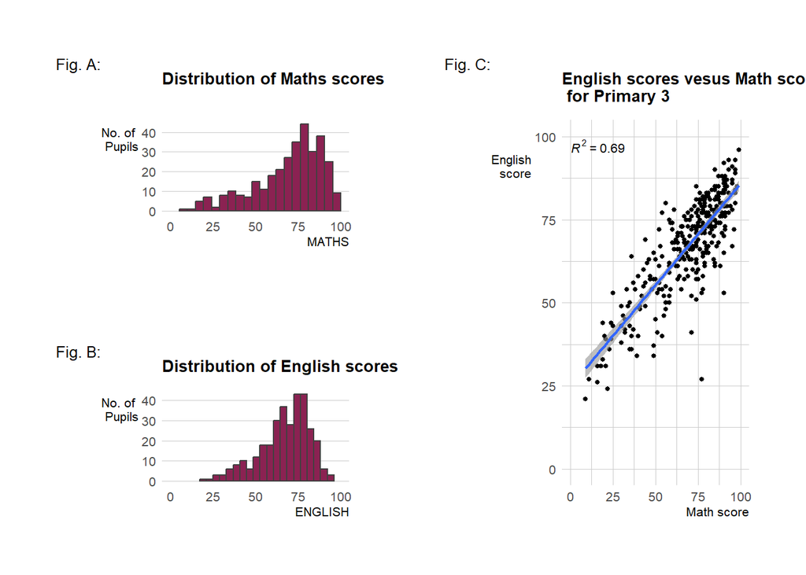

```r
((p1 / p2) | p3)  +
  plot_layout(tag_level = 'new') +
  plot_annotation(tag_levels = c('A', '1'), tag_prefix = 'Fig. ', tag_sep = '.',
                  tag_suffix = ':')
```

## 5.5 Creating figure with inset

Beside providing functions to place plots next to each other based on the provided layout. With [inset_element()](https://patchwork.data-imaginist.com/reference/inset_element.html) of **patchwork**, we can place one or several plots or graphic elements freely on top or below another plot.

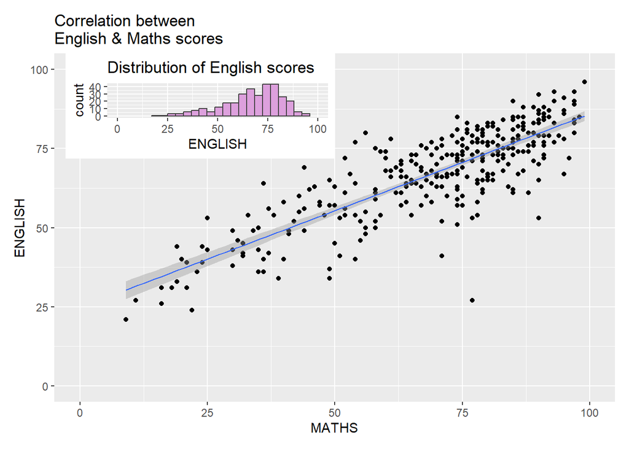

```r
p4 <- ggplot(data=exam_data,
             aes(x = ENGLISH)) +
  geom_histogram(bins=20,
                 boundary = 100,
                 color="grey25",
                 fill="plum") +
  coord_cartesian(xlim=c(0,100)) +
  ggtitle("Distribution of English scores")

p5 <- ggplot(data=exam_data,
             aes(x= MATHS,
                 y=ENGLISH)) +
  geom_point() +
  geom_smooth(method=lm,
              size=0.5) +
  coord_cartesian(xlim=c(0,100),
                  ylim=c(0,100)) +
  ggtitle("Correlation between\nEnglish & Maths scores")

p5 +  inset_element(p4,
                    left = 0.02,
                    bottom=0.7,
                    right= 0.5,
                    top=1)
```

## 5.6 Creating a composite figure by using patchwork and ggtheme

Figure below is created by combining patchwork and theme_economist() of ggthemes package discussed earlier.

**theme_economist**

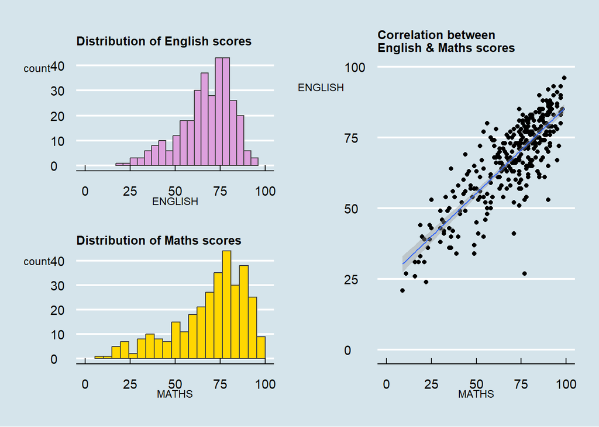

```r
p6 <- ggplot(data=exam_data,
             aes(x = MATHS)) +
  geom_histogram(bins=20,
                 boundary = 100,
                 color="grey25",
                 fill="gold") +
  coord_cartesian(xlim=c(0,100)) +
  ggtitle("Distribution of Maths scores")

patchwork <- ((p4/p6) | p5)

patchwork & theme_economist() +
  theme(plot.title=element_text(size =10),
                                        axis.title.y=element_text(size = 9,
                                                                  angle = 0,
                                                                  vjust=0.9),
                                         axis.title.x=element_text(size = 9))
```

**theme_solarized_2**

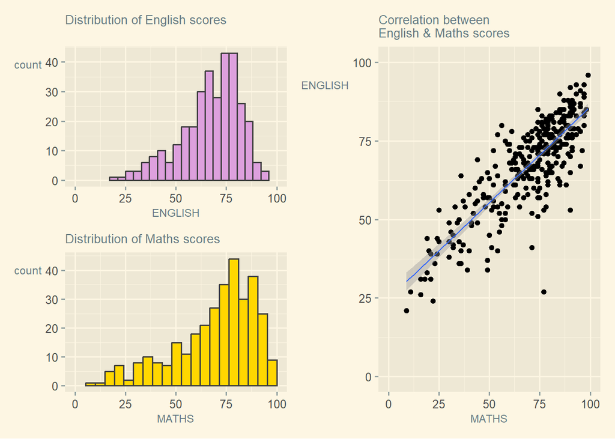

```r
patchwork & theme_solarized_2() +
  theme(plot.title=element_text(size =10),
                                        axis.title.y=element_text(size = 9,
                                                                  angle = 0,
                                                                  vjust=0.9),
                                         axis.title.x=element_text(size = 9))
```

## 6 References

- Kam, T.S. (2023). [Beyond ggplot2 Fundamentals](https://r4va.netlify.app/chap02).
- [Patchwork R package goes nerd viral](https://www.littlemissdata.com/blog/patchwork)
- [ggrepel](https://ggrepel.slowkow.com/)
- [ggthemes](https://ggplot2.tidyverse.org/reference/ggtheme.html)
- [hrbrthemes](https://r-graph-gallery.com/package/hrbrthemes.html)
- [ggplot tips: Arranging plots](https://ggplot2-book.org/arranging-plots.html)
- [ggplot2 Theme Elements Demonstration](https://henrywang.nl/ggplot2-theme-elements-demonstration/)
- [ggplot2 Theme Elements Reference Sheet](https://isabella-b.com/blog/ggplot2-theme-elements-reference/)